# To Swing or Not to Swing

David Cohn

October 14, 2023

In [part one](https://decohn.github.io/statcast-explorations/topics/situational-hitting/01.anatomy_of_a_double_play.html) of this series, I began my exploration of situational hitting by asking whether batters and pitchers alter their approaches in double play situations in an attempt to avoid or induce double plays, respectively. As a necessary first step, I constructed a *k*-nearest neighbours model to calculate the xGIDP (expected likelihood of a ground ball double play) for every batted ball, based on its launch speed and angle.

The logical next step is to ask whether xGIDP consistently differs - either for individual players or for the league as a whole - in double play situations. I can also explore some of the possible causes for any such difference, including pitch selection, pitch location, and swing decisions.

(NTS: this is getting very long and there’s still more analysis to add. think carefully about what actually belongs here and what should either be cut or moved to a later part)

## Part Two: To Swing or Not to Swing

### Load Data

In this analysis, we can make use of the pitch-by-pitch data that we retrieved using the Statcast search for the 2021 and 2022 regular seasons in Part One.

In addition to all of the columns that we retained in Part One, we’ll need some new ones, as we’d like to analyze pitch selection - both on the part of pitchers and batters. These additional columns are the following:

- bb_type
- pitch_type
- release_speed
- balls
- strikes
- pfx_x
- pfx_z
- plate_x
- plate_z
- sz_top
- sz_bot
- estimated_ba_using_speedangle
- pitcher…8 (renamed to pitcher_id)

```r
all_pitches <- read_csv(all_pitches_csv, show_col_types = FALSE) %>%
  select(
    game_date, player_name, events, description, stand, bb_type, on_1b, on_2b,
    on_3b, outs_when_up, launch_speed, launch_angle, pitch_type, release_speed,
    balls, strikes, pfx_x, pfx_z, plate_x, plate_z, sz_top, sz_bot,
    estimated_ba_using_speedangle, pitcher_id = pitcher...8
  )
```

### Clean Data

As in Part One, it will be advantageous to create and modify certain columns. All of the changes specified in Part One will be made, in addition to the following:

- An “is_ball_in_play” column that records whether the plate appearance ends on the pitch by virtue of the batter making contact
- An “is_PA” column that records whether the pitch ends a plate appearance, as defined in the denominator of on-base percentage
- An “is_AB” column that records whether the pitch ends an at-bat
- A “total_bases” column that records how many total bases were recorded by the batter on the pitch.

```r
all_pitches <- all_pitches %>%
  mutate(
    across(starts_with("on_"), ~ !is.na(.x)),
    is_ball_in_play = events %in% c(
      "single", "field_out", "home_run", "grounded_into_double_play",
      "force_out", "double", "triple", "sac_bunt", "field_error",
      "fielders_choice_out", "fielders_choice", "strikeout_double_play",
      "sac_fly_double_play", "triple_play", "double_play", "sac_fly"
    ),
    ended_PA = is_ball_in_play
      | events %in% c("walk", "strikeout", "hit_by_pitch", "catcher_interf"),
    is_PA = ended_PA & !(events %in% c("sac_bunt", "catcher_interf")),
    is_AB = is_PA & !(events %in% c("walk", "hit_by_pitch", "sac_fly")),
    total_bases = case_when(
      events == "single" ~ 1,
      events == "double" ~ 2,
      events == "triple" ~ 3,
      events == "home_run" ~ 4,
      TRUE ~ 0
    ),
    season = year(game_date),
    key = 1:nrow(all_pitches)
  )
```

We’ll also want to merge in the xGIDP calculations from Part One for every ball that was put in play.

```r
all_balls_in_play <-
  read_csv(xgidp_for_balls_in_play_csv, show_col_types = FALSE)

all_pitches <- left_join(all_pitches, all_balls_in_play)
```

And finally, we’ll want to convert the “pitcher_id” column into pitchers’ names. We can do this using the [Chadwick Baseball Bureau Register](https://github.com/chadwickbureau/register). As usual, we’ll save the data we download locally, to avoid having to download it repeatedly.

```r
write_csv(chadwick_player_lu(), chadwick_register_csv)
```

```r
player_register <- read_csv(chadwick_register_csv, show_col_types = FALSE) %>%
  filter(!is.na(key_mlbam)) %>%
  mutate(name_from_register = glue("{name_last}, {name_first}")) %>%
  select(key_mlbam, name_from_register)

all_pitches <- all_pitches %>%
  left_join(player_register, by = c("pitcher_id" = "key_mlbam")) %>%
  select(-pitcher_id) %>%
  rename(pitcher_name = name_from_register)
```

### Analysis

#### Batting Statistics in Double Play Situations

Let’s start by asking whether the average xGIDP of balls in play is different in double play situations vs. non-double play situations.

```r
all_pitches <- mutate(all_pitches, is_DP_situation = on_1b & (outs_when_up < 2))

summarize_batter_stats <- function(PAs, summary_column_name, caption) {
  batter_stats <- PAs %>%
    summarize(
      BA = sum(total_bases > 0) / sum(is_AB),
      OBP = (sum(total_bases > 0) + sum(events %in% c("walk", "hit_by_pitch")))
        / sum(is_PA),
      SLG = sum(total_bases) / sum(is_AB),
      BB_perc = 100 * sum(events == "walk") / sum(is_PA),
      K_perc = 100 * sum(events == "strikeout") / sum(is_PA),
      HR_perc = 100 * sum(events == "home_run") / sum(is_PA),
      xGIDP = mean(xGIDP, na.rm = TRUE),
      xBABIP = mean(estimated_ba_using_speedangle, na.rm = TRUE),
      .groups = "keep"
    )

  # calculate actual and expected BA for each type of ball in play
  BABIPs <- PAs %>%
    filter(!is.na(bb_type)) %>%
    group_by(bb_type, .add = TRUE) %>%
    summarize(
      BA = sum(total_bases > 0) / sum(is_AB),
      xBA = mean(estimated_ba_using_speedangle, na.rm = TRUE),
    ) %>%
    pivot_wider(names_from = bb_type, values_from = c("BA", "xBA"))

  batter_stats <- inner_join(batter_stats, BABIPs)

  return_kbl <- batter_stats %>%
    kable(
      align = rep("c", ncol(batter_stats)),
      digits = 3,
      col.names = c(
        summary_column_name, "BA", "OBP", "SLG", "BB%", "K%", "HR%", "xGIDP",
        "xBABIP", "BA on FBs", "BA on GBs", "BA on LDs", "BA on PUs",
        "xBA on FBs", "xBA on GBs", "xBA on LDs", "xBA on PUs"
      ),
      caption = caption
    ) %>%
    kable_styling(
      bootstrap_options = c("striped", "hover", "condensed", "responsive")
    )

  return(return_kbl)
}

all_pitches %>%
  filter(ended_PA) %>%
  group_by(is_DP_situation) %>%
  summarize_batter_stats(
    summary_column_name = "GIDP situation?",
    caption = "Batting statistics by the presence of a double play situation"
  )
```

Batting statistics by the presence of a double play situation

| GIDP situation? | BA | OBP | SLG | BB% | K% | HR% | xGIDP | xBABIP | BA on FBs | BA on GBs | BA on LDs | BA on PUs | xBA on FBs | xBA on GBs | xBA on LDs | xBA on PUs |
| --- | --- | --- | --- | --- | --- | --- | --- | --- | --- | --- | --- | --- | --- | --- | --- | --- |
| FALSE | 0.238 | 0.309 | 0.395 | 8.357 | 23.413 | 3.037 | 0.143 | 0.321 | 0.268 | 0.237 | 0.625 | 0.017 | 0.260 | 0.238 | 0.624 | 0.039 |
| TRUE | 0.267 | 0.324 | 0.439 | 7.236 | 20.555 | 3.310 | 0.141 | 0.320 | 0.296 | 0.256 | 0.670 | 0.021 | 0.261 | 0.233 | 0.627 | 0.039 |

The difference in xGIDP here (.143 vs. .141) isn’t significant, which is disappointing if you (like me) were hoping to discover evidence of situational hitting! There are still some interesting results here, though. The quality of contact that batters make isn’t altered in double-play situations (xBA of .321 vs. .320), but batting averages spike by nearly 30 points when the double-play is possible. The first explanation that comes to mind is that this results from the runner being held on first base, but the 19 point increase in batting average on ground balls is actually lower than the increase in batting average on line drives and fly balls.

To dig into this a bit further, we can try dividing plate appearances into smaller groups based on the precise base-out situation.

```r
# on_1b & (outs_when_up < 2) ~ "GIDP situation",
# on_1b & (outs_when_up == 2) ~ "Runner on 1st, 2 out",
# on_2b | on_3b ~ "Runner on 2nd or 3rd",
# TRUE ~ "Bases empty"

all_pitches <- all_pitches %>%
  mutate(
    base_out_situation = case_when(
      on_1b & !(on_2b | on_3b) & (outs_when_up < 2) ~ "Runner on 1st only, < 2 out",
      on_1b & !(on_2b | on_3b) & (outs_when_up == 2) ~ "Runner on 1st only, 2 out",
      on_1b & on_2b & (outs_when_up < 2) ~ "Runners on 1st and 2nd, < 2 out",
      on_1b & on_2b & (outs_when_up == 2) ~ "Runners on 1st and 2nd, 2 out",
      (!on_1b) & (on_2b | on_3b) ~ "Runner(s) on 2nd or 3rd, 1st base empty",
      !(on_1b | on_2b | on_3b) ~ "Bases empty"
    )
  )

all_pitches %>%
  filter(ended_PA) %>%
  group_by(base_out_situation) %>%
  summarize_batter_stats(
    summary_column_name = "Situation",
    caption = "Batting statistics by various base-out situations"
  )
```

Batting statistics by various base-out situations

| Situation | BA | OBP | SLG | BB% | K% | HR% | xGIDP | xBABIP | BA on FBs | BA on GBs | BA on LDs | BA on PUs | xBA on FBs | xBA on GBs | xBA on LDs | xBA on PUs |
| --- | --- | --- | --- | --- | --- | --- | --- | --- | --- | --- | --- | --- | --- | --- | --- | --- |
| Bases empty | 0.236 | 0.304 | 0.393 | 7.895 | 23.718 | 3.111 | 0.143 | 0.323 | 0.265 | 0.235 | 0.619 | 0.015 | 0.262 | 0.239 | 0.625 | 0.039 |
| Runner on 1st only, 2 out | 0.241 | 0.307 | 0.395 | 7.686 | 22.460 | 3.023 | 0.141 | 0.316 | 0.248 | 0.242 | 0.642 | 0.021 | 0.248 | 0.238 | 0.626 | 0.040 |
| Runner on 1st only, < 2 out | 0.262 | 0.324 | 0.433 | 7.212 | 20.595 | 3.391 | 0.140 | 0.320 | 0.273 | 0.261 | 0.648 | 0.021 | 0.262 | 0.234 | 0.627 | 0.038 |
| Runner(s) on 2nd or 3rd, 1st base empty | 0.248 | 0.332 | 0.404 | 10.644 | 22.595 | 2.756 | 0.145 | 0.317 | 0.293 | 0.249 | 0.648 | 0.025 | 0.258 | 0.233 | 0.619 | 0.041 |
| Runners on 1st and 2nd, 2 out | 0.231 | 0.311 | 0.388 | 8.955 | 23.945 | 2.933 | 0.144 | 0.320 | 0.276 | 0.223 | 0.620 | 0.016 | 0.261 | 0.237 | 0.625 | 0.041 |
| Runners on 1st and 2nd, < 2 out | 0.264 | 0.323 | 0.437 | 7.686 | 21.053 | 3.194 | 0.139 | 0.319 | 0.323 | 0.241 | 0.681 | 0.020 | 0.262 | 0.231 | 0.624 | 0.040 |
| NA | 0.281 | 0.320 | 0.450 | 6.860 | 19.780 | 2.980 | 0.148 | 0.316 | 0.366 | 0.257 | 0.720 | 0.017 | 0.256 | 0.229 | 0.629 | 0.041 |

We could check how individual players fare in these comparisons by making a leaderboard of individuals who greatly lower or raise their xGIDP in double play situations.

```r
get_individual_situational_xGIDP <- function(pitch_data, is_for_batters) {
  if(is_for_batters) {
    pitch_data <- pitch_data %>%
      group_by(player_name, season, stand, is_DP_situation)
  } else {
    pitch_data <- pitch_data %>%
      group_by(pitcher_name, season, is_DP_situation)
  }

  individual_situational_xGIDP <- pitch_data %>%
    filter(ended_PA) %>%
    filter(n() >= 50) %>%
    summarize(xGIDP = mean(xGIDP, na.rm = TRUE), .groups = "drop") %>%
    mutate(
      situation = if_else(is_DP_situation, "GIDP_situation", "other_situation"),
      is_DP_situation = NULL
    ) %>%
    pivot_wider(
      names_from = situation, values_from = xGIDP, names_prefix = "xGIDP_in_"
    ) %>%
    filter(if_all(starts_with("xGIDP"), ~ !is.na(.x))) %>%
    mutate(diff_xGIDP = xGIDP_in_GIDP_situation - xGIDP_in_other_situation)

  return(individual_situational_xGIDP)
}

get_diff_xGIDP_leaderboard <- function(individual_xGIDP, is_for_batters) {
  min_max_diff_xGIDP <- bind_rows(
    slice_min(individual_xGIDP, order_by = diff_xGIDP, n = 5),
    slice_max(individual_xGIDP, order_by = diff_xGIDP, n = 5)
  )

  kbl_col_names <- c(
    "Batter", "Season", "Bats", "xGIDP in non-GIDP situations",
    "xGIDP in GIDP situations", "xGIDP change in GIDP situations"
  )

  if(!is_for_batters) {
    kbl_col_names <- kbl_col_names[kbl_col_names != "Bats"]
  }

  leaderboard <- min_max_diff_xGIDP %>%
    kbl(
      col.names = kbl_col_names, digits = 3,
      align = rep("c", ncol(min_max_diff_xGIDP))
    ) %>%
    kable_styling(
      full_width = FALSE,
      bootstrap_options = c("striped", "hover", "condensed", "responsive")
    ) %>%
    pack_rows("Largest decrease in xGIDP", 1, 5) %>%
    pack_rows("Largest increase in xGIDP", 6, 10)

  return(leaderboard)
}

batter_situational_xGIDP <-
  get_individual_situational_xGIDP(all_pitches, is_for_batters = TRUE)

pitcher_situational_xGIDP <-
  get_individual_situational_xGIDP(all_pitches, is_for_batters = FALSE)

get_diff_xGIDP_leaderboard(batter_situational_xGIDP, is_for_batters = TRUE)
```

| Batter | Season | Bats | xGIDP in non-GIDP situations | xGIDP in GIDP situations | xGIDP change in GIDP situations |
| --- | --- | --- | --- | --- | --- |
| **Largest decrease in xGIDP** |  |  |  |  |  |
| Perdomo, Geraldo | 2022 | L | 0.161 | 0.074 | -0.087 |
| Bell, Josh | 2021 | R | 0.224 | 0.152 | -0.071 |
| Senzel, Nick | 2022 | R | 0.170 | 0.101 | -0.069 |
| Franco, Maikel | 2021 | R | 0.183 | 0.114 | -0.069 |
| Ramírez, Harold | 2022 | R | 0.186 | 0.119 | -0.067 |
| **Largest increase in xGIDP** |  |  |  |  |  |
| Cordero, Franchy | 2022 | L | 0.105 | 0.183 | 0.078 |
| Berti, Jon | 2022 | R | 0.162 | 0.234 | 0.072 |
| Zimmerman, Ryan | 2021 | R | 0.144 | 0.215 | 0.071 |
| Frazier, Adam | 2021 | L | 0.138 | 0.209 | 0.071 |
| Hicks, Aaron | 2022 | L | 0.117 | 0.187 | 0.070 |

```r
get_diff_xGIDP_leaderboard(
  pitcher_situational_xGIDP, is_for_batters = FALSE
)
```

| Batter | Season | xGIDP in non-GIDP situations | xGIDP in GIDP situations | xGIDP change in GIDP situations |
| --- | --- | --- | --- | --- |
| **Largest decrease in xGIDP** |  |  |  |  |
| Scott, Tanner | 2021 | 0.199 | 0.094 | -0.105 |
| Stratton, Chris | 2021 | 0.161 | 0.081 | -0.079 |
| Rodríguez, Joely | 2022 | 0.194 | 0.119 | -0.075 |
| Coleman, Dylan | 2022 | 0.146 | 0.075 | -0.071 |
| Maton, Phil | 2021 | 0.149 | 0.086 | -0.063 |
| **Largest increase in xGIDP** |  |  |  |  |
| Soto, Gregory | 2022 | 0.143 | 0.246 | 0.102 |
| Sampson, Adrian | 2022 | 0.120 | 0.208 | 0.088 |
| Barlow, Scott | 2022 | 0.128 | 0.215 | 0.088 |
| Archer, Chris | 2022 | 0.122 | 0.209 | 0.087 |
| Moore, Matt | 2022 | 0.134 | 0.219 | 0.085 |

Then correlate 2021 and 2022 values for these players to see if there’s any evidence that selectively raising/lowering xGIDP in these situations is a repeatable skill.

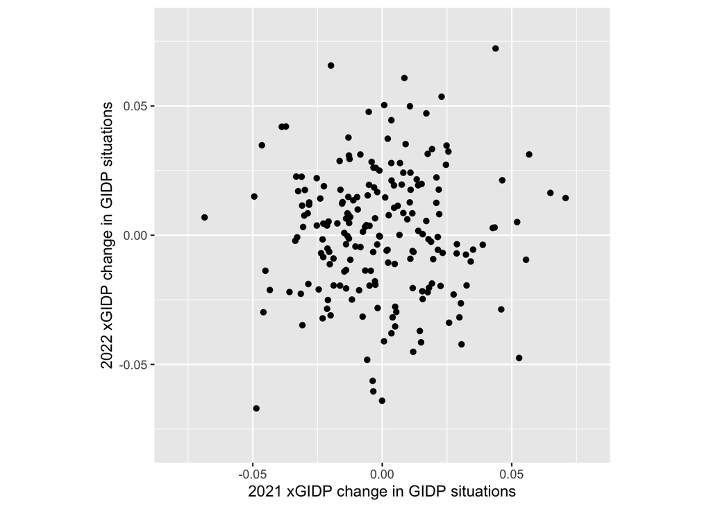

```r
plot_season_diff_xGIDP_correlations <- function(xGIDP_leaderboard) {
  yearly_individual_situational_xGIDP <- xGIDP_leaderboard %>%
    select(-starts_with("xGIDP")) %>%
    pivot_wider(
      names_from = season, values_from = diff_xGIDP,
      names_prefix = "diff_xGIDP_"
    ) %>%
    filter(if_all(starts_with("diff_xGIDP_"), ~ !is.na(.x)))

  yearly_xGIDP_plot <- yearly_individual_situational_xGIDP %>%
    ggplot(aes(x = diff_xGIDP_2021, y = diff_xGIDP_2022)) +
    geom_point() +
    coord_equal() +
    xlim(c(-0.08, 0.08)) +
    ylim(c(-0.08, 0.08)) +
    xlab("2021 xGIDP change in GIDP situations") +
    ylab("2022 xGIDP change in GIDP situations")

  plot(yearly_xGIDP_plot)

  return(yearly_individual_situational_xGIDP)
}

batter_yearly_situational_xGIDP <-
  plot_season_diff_xGIDP_correlations(batter_situational_xGIDP)
```

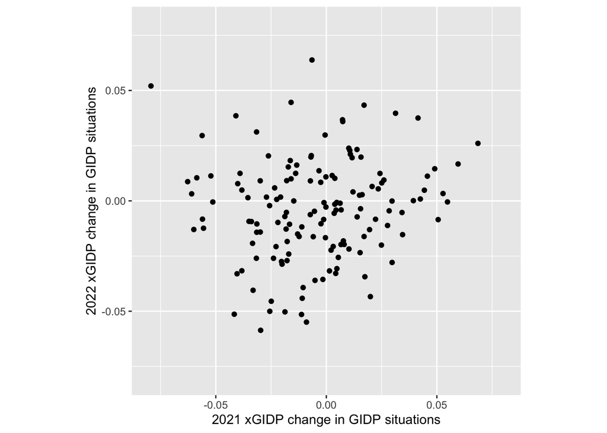

```r
pitcher_yearly_situational_xGIDP <-
  plot_season_diff_xGIDP_correlations(pitcher_situational_xGIDP)
```

Well, it … sure looks like there’s nothing doing here. The r<sup>2</sup> value here is 0 for batters, and 0 for pitchers.

### Do pitchers or batters specifically attempt to induce/avoid GIDPs?

While there doesn’t appear to be any evidence that pitchers or batters successfully induce or avoid GIDPs, respectively, it may still be interesting to ask whether any players *attempt* to do so.

Certain types of pitches and certain pitch locations may be more likely to result in GIDPs. We can ask a) do pitchers throw more GIDP-inducing pitches when in GIDP situations, and b) are batters less likely to swing at GIDP-inducing pitches when in GIDP situations?

We’ll first have to scale the height of pitches to each individual batter’s strike zone - a pitch that’s below the knees of a tall batter might actually be a strike to a shorter batter. We’ll also redefine the horizontal coordinate of pitch location and pitch break to account for the batter’s handedness, such that negative values always represent inside pitches and positive values represent outside pitches.

```r
all_pitches <- all_pitches %>%
  mutate(
    scaled_plate_z = 1.5 + 2 * (plate_z - sz_bot) / (sz_top - sz_bot),
    scaled_plate_x = if_else(stand == "L", -plate_x, plate_x),
    scaled_pfx_x = if_else(stand == "L", -pfx_x, pfx_x),
    pitch_group = case_when(
      pitch_type %in% c('FF', 'FC', 'SI', 'FA') ~ 'Fastball',
      pitch_type %in% c('SL', 'CU', 'KC', 'KN', 'EP', 'ST', 'SV') ~ 'Breaking',
      pitch_type %in% c('FS', 'CH', 'FO', 'SC') ~ 'Off-speed',
      TRUE ~ NA
    )
  )
```

Now we can examine how pitch location, pitch type, and break are associated with xGIDP.

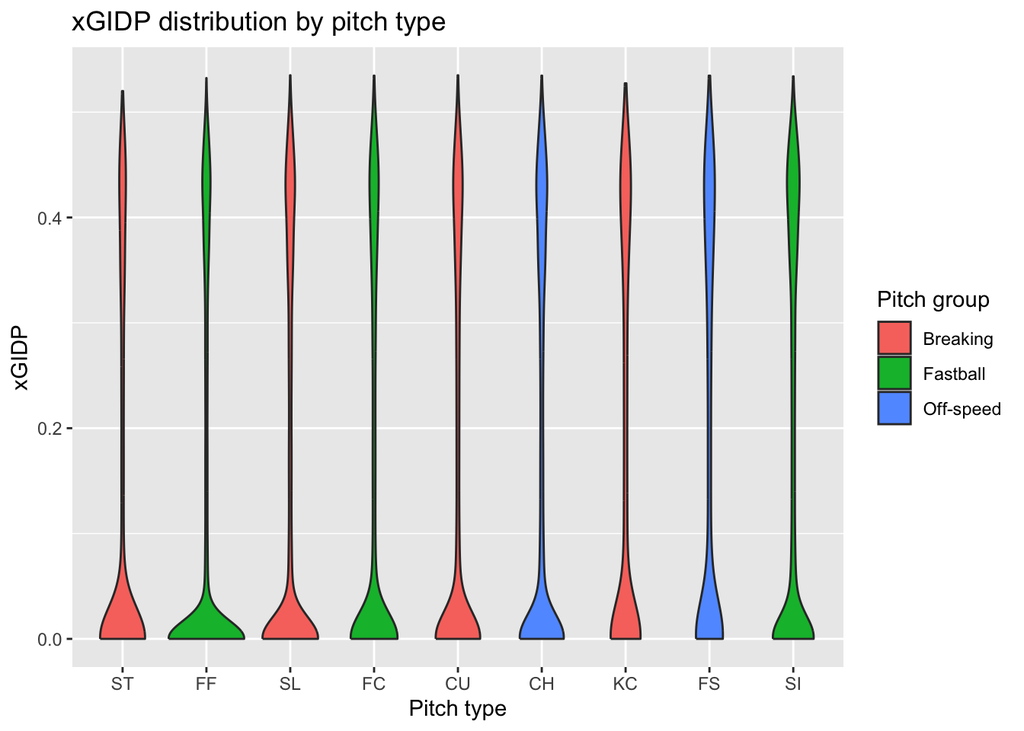

```r
xgidp_by_pitch_characteristics <- all_pitches %>%
  filter(
    if_all(
      c("xGIDP", "scaled_plate_x", "scaled_plate_z", "scaled_pfx_x", "pfx_z"),
      ~ !is.na(.x)
    )
  ) %>%
  select(
    pitch_group, pitch_type, release_speed, scaled_plate_x, scaled_plate_z,
    scaled_pfx_x, pfx_z, xGIDP
  )

major_pitches <- xgidp_by_pitch_characteristics %>%
  filter(n() > 1000, .by = pitch_type) %>%
  pull(pitch_type) %>%
  unique()

xgidp_by_pitch_characteristics %>%
  filter(pitch_type %in% major_pitches) %>%
  ggplot(aes(x = fct_reorder(pitch_type, xGIDP, .fun = mean), y = xGIDP)) +
  geom_violin(aes(fill = pitch_group)) +
  labs(
    title = "xGIDP distribution by pitch type",
    x = "Pitch type",
    fill = "Pitch group"
  )
```

It seems like sinkers (SI) and splitters (FS) are the most effective pitches at inducing double plays, while sweepers (ST) and four-seam fastballs (FF) are the least effective.

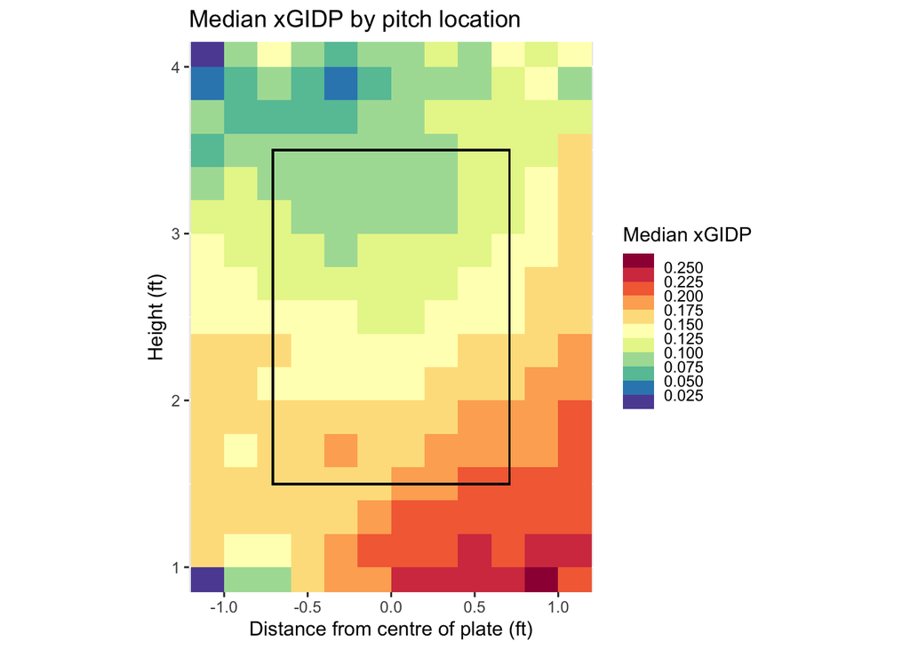

```r
xgidp_by_pitch_characteristics %>%
  filter(
    between(scaled_plate_x, -1.2, 1.2) & between(scaled_plate_z, 0.9, 4.1)
  ) %>%
  ggplot() +
  stat_summary_2d(
    aes(x = scaled_plate_x, y = scaled_plate_z, z = xGIDP), binwidth = 0.2
  ) +
  scale_fill_fermenter(palette = "Spectral", n.breaks = 10) +
  geom_rect(
    aes(xmin = -17/24, xmax = 17/24, ymin = 1.5, ymax = 3.5),
    colour = "black",
    fill = NA
  ) +
  coord_equal(xlim = c(-1.1, 1.1), ylim = c(1, 4)) +
  labs(
    x = "Distance from centre of plate (ft)",
    y = "Height (ft)",
    fill = "Median xGIDP",
    title = "Median xGIDP by pitch location"
  )
```

xGIDP is clearly highest for low pitches and outside pitches: pitches both down and away reach xGIDPs of > 0.2, while pitches up and in have xGIDPs of < 0.1.

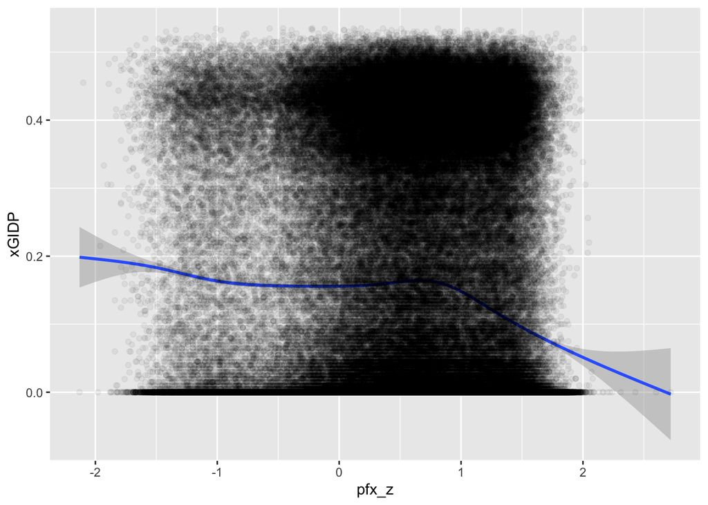

```r
xgidp_by_pitch_characteristics %>%
  ggplot(mapping = aes(x = pfx_z, y = xGIDP)) +
  geom_smooth() +
  geom_point(alpha = 0.05)
```

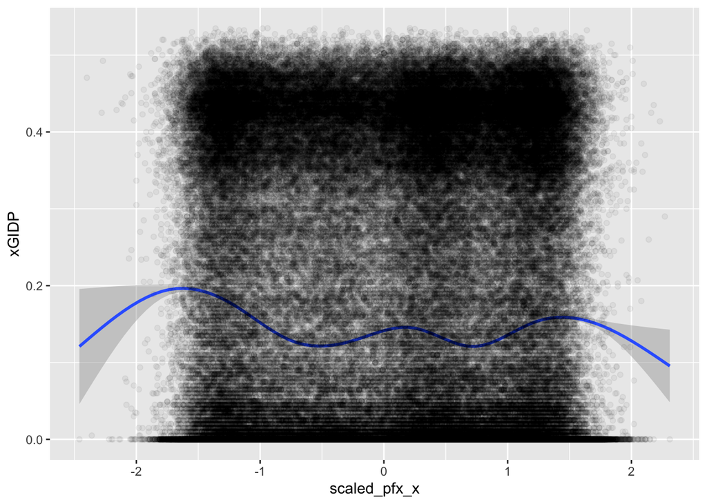

```r
xgidp_by_pitch_characteristics %>%
  ggplot(mapping = aes(x = scaled_pfx_x, y = xGIDP)) +
  geom_smooth() +
  geom_point(alpha = 0.05)
```

Obviously these factors all confound upon each other, so a linear model might probably be necessary at some point. In the meantime, I’ll generate a table that includes the median xGIDP for each pitch type, along with its median location and break.

```r
xgidp_by_pitch_summary_table <- xgidp_by_pitch_characteristics %>%
  filter(pitch_type %in% major_pitches, .by = pitch_type) %>%
  summarize(
    count = n(),
    mean_xGIDP = mean(xGIDP),
    across(
      c(
        "release_speed", "scaled_plate_x", "scaled_plate_z", "scaled_pfx_x",
        "pfx_z"
      ),
      median,
      .names = "median_{.col}"
    ),
    .by = pitch_type
  ) %>%
  arrange(desc(mean_xGIDP))

xgidp_by_pitch_summary_table %>%
  kable(
    align = rep("c", ncol(xgidp_by_pitch_summary_table)),
    digits = 2,
    col.names = c(
      "Pitch", "Count", "Mean xGIDP", "Median speed (mph)",
      "Median x coordinate (ft)", "Median z coordinate (ft)",
      "Median horizontal break (ft)", "Median vertical break (ft)"
    ),
    caption = "xGIDP, location, and break by pitch type"
  ) %>%
  kable_styling(
    bootstrap_options = c("striped", "hover", "condensed", "responsive")
  )
```

xGIDP, location, and break by pitch type

| Pitch | Count | Mean xGIDP | Median speed (mph) | Median x coordinate (ft) | Median z coordinate (ft) | Median horizontal break (ft) | Median vertical break (ft) |
| --- | --- | --- | --- | --- | --- | --- | --- |
| SI | 44685 | 0.18 | 93.2 | -0.11 | 2.36 | -0.97 | 0.75 |
| FS | 3883 | 0.18 | 86.3 | 0.26 | 2.02 | 0.74 | 0.33 |
| KC | 4627 | 0.17 | 81.2 | 0.14 | 2.08 | -0.10 | -0.90 |
| CH | 31450 | 0.16 | 85.2 | 0.39 | 2.04 | 1.12 | 0.56 |
| CU | 15789 | 0.14 | 79.0 | 0.17 | 2.09 | -0.27 | -0.83 |
| FC | 18482 | 0.14 | 88.5 | 0.01 | 2.41 | 0.02 | 0.66 |
| SL | 40693 | 0.14 | 85.2 | 0.18 | 2.13 | 0.21 | 0.15 |
| FF | 79150 | 0.11 | 93.8 | -0.04 | 2.67 | 0.21 | 1.34 |
| ST | 4738 | 0.11 | 81.5 | 0.26 | 2.18 | 1.05 | 0.05 |

What we really care about though is: do pitchers shift what they throw, and do they shift where they throw it?

```r
situational_arsenal <- all_pitches %>%
  filter(pitch_type %in% major_pitches) %>%
  summarize(count = n(), .by = c("pitch_type", "base_out_situation")) %>%
  pivot_wider(names_from = base_out_situation, values_from = count) %>%
  mutate(across(!pitch_type, ~ .x / sum(.x))) %>%
  arrange(desc(`Bases empty`))

situational_arsenal %>%
  kbl(digits = 3, align = rep("c", ncol(situational_arsenal))) %>%
  kable_styling(
    full_width = FALSE,
    bootstrap_options = c("striped", "hover", "condensed", "responsive")
  )
```

| pitch_type | Bases empty | Runner on 1st only, < 2 out | Runner(s) on 2nd or 3rd, 1st base empty | Runners on 1st and 2nd, < 2 out | NA | Runner on 1st only, 2 out | Runners on 1st and 2nd, 2 out |
| --- | --- | --- | --- | --- | --- | --- | --- |
| FF | 0.356 | 0.334 | 0.322 | 0.311 | 0.318 | 0.350 | 0.333 |
| SL | 0.172 | 0.171 | 0.203 | 0.198 | 0.194 | 0.180 | 0.206 |
| SI | 0.152 | 0.179 | 0.139 | 0.177 | 0.168 | 0.153 | 0.144 |
| CH | 0.111 | 0.121 | 0.117 | 0.114 | 0.112 | 0.113 | 0.106 |
| CU | 0.081 | 0.066 | 0.080 | 0.071 | 0.076 | 0.073 | 0.073 |
| FC | 0.069 | 0.075 | 0.073 | 0.070 | 0.075 | 0.071 | 0.073 |
| KC | 0.023 | 0.019 | 0.023 | 0.020 | 0.021 | 0.021 | 0.020 |
| ST | 0.021 | 0.019 | 0.025 | 0.023 | 0.022 | 0.023 | 0.026 |
| FS | 0.015 | 0.016 | 0.018 | 0.016 | 0.015 | 0.016 | 0.017 |

Hmm… this is interesting, but I wouldn’t mind calculating the proportions for each pitch based ONLY on pitchers that actually have such pitches in their arsenal.

pitchers_throwing_pitchers is a named vector where the names are pitch codes and the values are the pitchers who have the pitches in their arsenal.

```r
pitches_by_pitcher <- all_pitches %>%
  summarize(pitches = n(), .by = pitcher_name)

eligible_pitchers <- pitches_by_pitcher %>%
  filter(pitches >= 200) %>%
  pull(pitcher_name)

pitchers_throwing_pitches <- all_pitches %>%
  filter(pitcher_name %in% eligible_pitchers) %>%
  summarize(count = n(), .by = c("pitch_type", "pitcher_name")) %>%
  mutate(
    frequency = count / sum(count),
    count = NULL,
    .by = pitcher_name
  ) %>%
  filter(frequency >= 0.03) %>%
  summarize(
    pitchers = list(pitcher_name),
    .by = pitch_type
  ) %>%
  deframe()

get_pitch_usage_by_situation <- function(pitch) {
  usage_by_situation <- all_pitches %>%
    filter(pitcher_name %in% pitchers_throwing_pitches[[pitch]]) %>%
    summarize(count = n(), .by = c("pitch_type", "base_out_situation")) %>%
    mutate(
      frequency = count / sum(count),
      count = NULL,
      .by = base_out_situation
    ) %>%
    filter(pitch_type == pitch)

  return(usage_by_situation)
}

situational_arsenals <- map(major_pitches, get_pitch_usage_by_situation) %>%
  bind_rows() %>%
  pivot_wider(names_from = base_out_situation, values_from = frequency)

situational_arsenals %>%
  kbl(digits = 3, align = rep("c", ncol(situational_arsenals))) %>%
  kable_styling(
    full_width = FALSE,
    bootstrap_options = c("striped", "hover", "condensed", "responsive")
  )
```

| pitch_type | Bases empty | Runner(s) on 2nd or 3rd, 1st base empty | Runners on 1st and 2nd, < 2 out | Runner on 1st only, < 2 out | NA | Runner on 1st only, 2 out | Runners on 1st and 2nd, 2 out |
| --- | --- | --- | --- | --- | --- | --- | --- |
| FF | 0.392 | 0.356 | 0.347 | 0.370 | 0.357 | 0.387 | 0.373 |
| SI | 0.259 | 0.238 | 0.295 | 0.301 | 0.275 | 0.261 | 0.251 |
| FC | 0.195 | 0.220 | 0.224 | 0.219 | 0.223 | 0.210 | 0.232 |
| CH | 0.151 | 0.164 | 0.163 | 0.166 | 0.158 | 0.156 | 0.156 |
| SL | 0.229 | 0.270 | 0.261 | 0.227 | 0.257 | 0.239 | 0.272 |
| FS | 0.175 | 0.207 | 0.205 | 0.185 | 0.190 | 0.185 | 0.200 |
| CU | 0.155 | 0.162 | 0.148 | 0.129 | 0.153 | 0.144 | 0.157 |
| KC | 0.180 | 0.192 | 0.190 | 0.156 | 0.192 | 0.170 | 0.195 |
| ST | 0.197 | 0.240 | 0.230 | 0.188 | 0.223 | 0.213 | 0.259 |

```r
ff_si_pitchers <- intersect(pitchers_throwing_pitches[["FF"]], pitchers_throwing_pitches[["SI"]])

ff_si_pitcher_situational_arsenal <- all_pitches %>%
  filter(
    pitch_type %in% c("FF", "SI"),
    pitcher_name %in% ff_si_pitchers
  ) %>%
  summarize(count = n(), .by = c("pitch_type", "is_DP_situation")) %>%
  pivot_wider(names_from = is_DP_situation, values_from = count) %>%
  mutate(across(!pitch_type, ~ .x / sum(.x)))

ff_si_pitcher_situational_arsenal %>%
  kbl(
    digits = 3, align = rep("c", ncol(ff_si_pitcher_situational_arsenal)),
    col.names = c("Pitch", "Not GIDP Situation", "GIDP Situation"),
    caption = "Relative pitch frequencies for pitchers throwing FFs and SIs"
  ) %>%
  kable_styling(
    full_width = FALSE,
    bootstrap_options = c("striped", "hover", "condensed", "responsive")
  )
```

Relative pitch frequencies for pitchers throwing FFs and SIs

| Pitch | Not GIDP Situation | GIDP Situation |
| --- | --- | --- |
| FF | 0.572 | 0.5 |
| SI | 0.428 | 0.5 |

And now let’s break that down by individual pitchers and by season, so that we can try to see if this is a consistent trend.

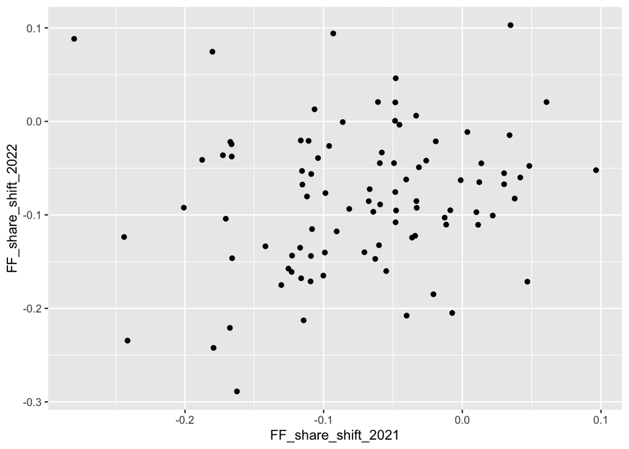

```r
ff_si_pitcher_situational_arsenals <- all_pitches %>%
  filter(
    pitch_type %in% c("FF", "SI"),
    pitcher_name %in% ff_si_pitchers
  ) %>%
  summarize(count = n(), .by = c("pitcher_name", "season", "pitch_type", "is_DP_situation"))

eligible_ff_si_pitchers <- ff_si_pitcher_situational_arsenals %>%
  filter(count >= 20) %>%
  count(pitcher_name) %>%
  filter(n == 8) %>%
  pull(pitcher_name)

ff_si_pitcher_situational_arsenals <- ff_si_pitcher_situational_arsenals %>%
  filter(pitcher_name %in% eligible_ff_si_pitchers) %>%
  pivot_wider(names_from = pitch_type, values_from = count) %>%
  mutate(FF_share = FF / (FF + SI)) %>%
  select(-c("FF", "SI")) %>%
  pivot_wider(names_from = is_DP_situation, names_prefix = "FF_share_", values_from = FF_share) %>%
  mutate(FF_share_shift_in_GIDP = FF_share_TRUE - FF_share_FALSE) %>%
  select(-c("FF_share_TRUE", "FF_share_FALSE")) %>%
  pivot_wider(names_from = season, names_prefix = "FF_share_shift_", values_from = FF_share_shift_in_GIDP)

ggplot(ff_si_pitcher_situational_arsenals) +
  geom_point(mapping = aes(x = FF_share_shift_2021, y = FF_share_shift_2022))
```

The r<sup>2</sup> value here is 0.028.

This is a really, really weak correlation. Not a lot of evidence that the habits of these pitchers are consistent from year-to-year.

TODO: continue onward with pitch *location*??